# Developing an AI application

Going forward, AI algorithms will be incorporated into more and more everyday applications. For example, you might want to include an image classifier in a smart phone app. To do this, you'd use a deep learning model trained on hundreds of thousands of images as part of the overall application architecture. A large part of software development in the future will be using these types of models as common parts of applications.

In this project, you'll train an image classifier to recognize different species of flowers. You can imagine using something like this in a phone app that tells you the name of the flower your camera is looking at. In practice you'd train this classifier, then export it for use in your application. We'll be using [this dataset](http://www.robots.ox.ac.uk/~vgg/data/flowers/102/index.html) of 102 flower categories, you can see a few examples below.

[figure not shown]

The project is broken down into multiple steps:

- Load and preprocess the image dataset
- Train the image classifier on your dataset
- Use the trained classifier to predict image content

We'll lead you through each part which you'll implement in Python.

When you've completed this project, you'll have an application that can be trained on any set of labeled images. Here your network will be learning about flowers and end up as a command line application. But, what you do with your new skills depends on your imagination and effort in building a dataset. For example, imagine an app where you take a picture of a car, it tells you what the make and model is, then looks up information about it. Go build your own dataset and make something new.

First up is importing the packages you'll need. It's good practice to keep all the imports at the beginning of your code. As you work through this notebook and find you need to import a package, make sure to add the import up here.

```python
# Imports
%matplotlib inline
%config InlineBackend.figure_format = 'retina'

import matplotlib.pyplot as plt
import math
import time
import copy
import numpy as np
from PIL import Image
import os
import sys

from workspace_utils import active_session

# Import Pytorch modules
import torch
from torch import optim, nn
import torch.nn.functional as F
from torchvision import datasets, transforms, models
```

## Load the data

Here you'll use `torchvision` to load the data ([documentation](http://pytorch.org/docs/0.3.0/torchvision/index.html)). The data should be included alongside this notebook, otherwise you can [download it here](https://s3.amazonaws.com/content.udacity-data.com/nd089/flower_data.tar.gz). The dataset is split into three parts, training, validation, and testing. For the training, you'll want to apply transformations such as random scaling, cropping, and flipping. This will help the network generalize leading to better performance. You'll also need to make sure the input data is resized to 224x224 pixels as required by the pre-trained networks.

The validation and testing sets are used to measure the model's performance on data it hasn't seen yet. For this you don't want any scaling or rotation transformations, but you'll need to resize then crop the images to the appropriate size.

The pre-trained networks you'll use were trained on the ImageNet dataset where each color channel was normalized separately. For all three sets you'll need to normalize the means and standard deviations of the images to what the network expects. For the means, it's `[0.485, 0.456, 0.406]` and for the standard deviations `[0.229, 0.224, 0.225]`, calculated from the ImageNet images. These values will shift each color channel to be centered at 0 and range from -1 to 1.

```python
# General setup
###############

# Training phases
phases = ['train', 'valid', 'test']

# Training Images Details
IMG_SIZE = 224  # Size of images used for training
IMG_MEAN = [0.485, 0.456, 0.406]
IMG_SDEV = [0.229, 0.224, 0.225]

# Define data locations
data_dir = {n: 'flowers/' + n for n in phases}
```

```python
# Define transforms for the training, validation, and testing sets
data_transforms = {
    'train': transforms.Compose([
        transforms.RandomRotation(30),
        transforms.RandomResizedCrop(IMG_SIZE),
        transforms.RandomHorizontalFlip(p=0.5),
        transforms.ToTensor(),
        transforms.Normalize(IMG_MEAN, IMG_SDEV)
    ]),
    'valid': transforms.Compose([
        transforms.Resize(256),
        transforms.CenterCrop(IMG_SIZE),
        transforms.ToTensor(),
        transforms.Normalize(IMG_MEAN, IMG_SDEV)
    ]),
    'test': transforms.Compose([
        transforms.Resize(256),
        transforms.CenterCrop(IMG_SIZE),
        transforms.ToTensor(),
        transforms.Normalize(IMG_MEAN, IMG_SDEV)
    ])
}
```

```python
# Load the datasets
image_datasets = {n: datasets.ImageFolder(data_dir[n], transform=data_transforms[n]) for n in phases}

# Define the PyTorch dataloaders
dataloaders = {n: torch.utils.data.DataLoader(image_datasets[n], batch_size=64, shuffle=True) for n in phases}
```

### Label mapping

You'll also need to load in a mapping from category label to category name. You can find this in the file `cat_to_name.json`. It's a JSON object which you can read in with the [`json` module](https://docs.python.org/2/library/json.html). This will give you a dictionary mapping the integer encoded categories to the actual names of the flowers.

```python
import json

with open('cat_to_name.json', 'r') as f:
    cat_to_name = json.load(f)

print(len(list(cat_to_name.keys())))
```

```
102
```

# Building and training the classifier

Now that the data is ready, it's time to build and train the classifier. As usual, you should use one of the pretrained models from `torchvision.models` to get the image features. Build and train a new feed-forward classifier using those features.

We're going to leave this part up to you. Refer to [the rubric](https://review.udacity.com/#!/rubrics/1663/view) for guidance on successfully completing this section. Things you'll need to do:

- Load a [pre-trained network](http://pytorch.org/docs/master/torchvision/models.html) (If you need a starting point, the VGG networks work great and are straightforward to use)
- Define a new, untrained feed-forward network as a classifier, using ReLU activations and dropout
- Train the classifier layers using backpropagation using the pre-trained network to get the features
- Track the loss and accuracy on the validation set to determine the best hyperparameters

We've left a cell open for you below, but use as many as you need. Our advice is to break the problem up into smaller parts you can run separately. Check that each part is doing what you expect, then move on to the next. You'll likely find that as you work through each part, you'll need to go back and modify your previous code. This is totally normal!

When training make sure you're updating only the weights of the feed-forward network. You should be able to get the validation accuracy above 70% if you build everything right. Make sure to try different hyperparameters (learning rate, units in the classifier, epochs, etc) to find the best model. Save those hyperparameters to use as default values in the next part of the project.

One last important tip if you're using the workspace to run your code: To avoid having your workspace disconnect during the long-running tasks in this notebook, please read in the earlier page in this lesson called Intro to GPU Workspaces about Keeping Your Session Active. You'll want to include code from the workspace_utils.py module.

**Note for Workspace users:** If your network is over 1 GB when saved as a checkpoint, there might be issues with saving backups in your workspace. Typically this happens with wide dense layers after the convolutional layers. If your saved checkpoint is larger than 1 GB (you can open a terminal and check with `ls -lh`), you should reduce the size of your hidden layers and train again.

## FC Classifier Network

Builds neural network with hidden layers for use in transfer learning with torchvision models. FC Classifier general architecture:

- Input:
  - fc0: Linear()
- Hidden1 (optional):
  - relu1: ReLU()
  - drop1: Dropout()
  - fc1: Linear()
- Hidden2 (optional):
  - relu2: ReLU()
  - drop2: Dropout()
  - fc2: Linear()
- ...
- Output: LogSoftmax()

```python
# Create Classifier Network
class FCClassifier(nn.Module):
    def __init__(self, input_size, output_size, hidden_layers, drop_p=0.5):
        """Builds neural network with hidden layers for use in transfer learning with torchvision models.

        Args:
            input_size (int): size of input layer
            output_size (int): size of output layer
            hidden_layers ([int]): array holding integer sizes of hidden layers
            drop_p (float (0, 1)): dropout probability

        Params:
            classifier: fully connected layer(s) for use as final classifier layers in transfer learning
        """
        super().__init__()

        # set all layer sizes
        layer_sizes = [input_size] + hidden_layers + [output_size]

        # build layers
        self.classifier = nn.Sequential()
        for idx, (inp, out) in enumerate(zip(layer_sizes[:-1], layer_sizes[1:])):
            # add FC linear layer
            self.classifier.add_module('fc' + str(idx), nn.Linear(inp, out))
            # add ReLU and Dropout before hidden layers
            if idx < (len(layer_sizes) - 2):
                self.classifier.add_module('relu' + str(idx + 1), nn.ReLU())
                self.classifier.add_module('dropout' + str(idx + 1), nn.Dropout(drop_p))
        # Return LogSoftMax
        self.classifier.add_module('output', nn.LogSoftmax(dim=1))
```

```python
# Test FCClassifier class
fcc = FCClassifier(input_size=20588, output_size=102, hidden_layers=[2048, 512], drop_p=0.5)
print(fcc.classifier)
```

```
Sequential(
  (fc0): Linear(in_features=20588, out_features=2048, bias=True)
  (relu1): ReLU()
  (dropout1): Dropout(p=0.5)
  (fc1): Linear(in_features=2048, out_features=512, bias=True)
  (relu2): ReLU()
  (dropout2): Dropout(p=0.5)
  (fc2): Linear(in_features=512, out_features=102, bias=True)
  (output): LogSoftmax()
)
```

## Helper functions

- create_model(): creates classifier neural net model with pre-trained torchvision.model base layers
- create_optimizer(): creates Adam optimizer for model training
- select_device(): selects GPU or CPU device and checks for GPU availability
- train_model(): trains classifier model. At the end of training sets model and optimizer state_dict to state after trainig epoch with the highest validation accuracy.
- plot_history(): plots training/validation accuracy and losses

```python
# Create classifier model with pre-trained torchvision model base layers and custom classifier
def create_model(arch='vgg16', output_size=102, class_to_idx=None, hidden_layers=[4096, 4096], drop_p=0.5):
    """Builds neural network with pre-trained torchvision model base and custom fully connected
       classifier final layer(s) with attached training class to index
       mapping dictionary.

        Args:
            arch (str): pre-trained torchvision model name.
                        Supported models ['alexnet', 'densenet161', 'resnet18', 'vgg16']
            output_size (int): size of output layer
            hidden_layers ([int], None): array holding integer sizes of hidden layers.
            drop_p (float (0, 1)): dropout probability
            class_to_idx (dict): mapping of training classes to indices

        Returns:
            model (nn model): pre-trained model with custom classifier.
                              Attributes:
                                  arch
                                  class_to_idx
                                  output_size
                                  hidden_layers
                                  drop_p


        """
    # Supported models dict(): keys = model name, values = classifier inputsize
    supported_models = {'alexnet': 9216,
                        'densenet161': 2208,
                        'resnet18': 512,
                        'vgg16': 25088}

    # Define model classifier input size to match pre-trained model architecture
    try:
        input_size = supported_models[arch]
    except KeyError:
        print(f'Exception: Architecture {arch} is not one of supported'
              f' model architectures: {list(supported_models.keys())}.')
        sys.exit(1)

    # Load model
    model = getattr(models, arch)(pretrained=True)

    # Freeze pre-trained model parameters
    for param in model.parameters():
        param.requires_grad = False

    # Create custom classifier
    fc = FCClassifier(input_size=input_size, output_size=output_size,
                      hidden_layers=hidden_layers, drop_p=drop_p).classifier

    # Replace pre-trained model classifer layer(s) with custom classifier
    if arch == 'resnet18':
        model.fc = fc
    else:
        model.classifier = fc

    # Attach relevant model information for future reference
    model.arch = arch
    model.class_to_idx = class_to_idx
    model.output_size = output_size
    model.hidden_layers = hidden_layers
    model.drop_p = drop_p

    return model
```

```python
# Test create_model
model = create_model(arch='resnet18')
print(model)
```

```
ResNet(
  (conv1): Conv2d(3, 64, kernel_size=(7, 7), stride=(2, 2), padding=(3, 3), bias=False)
  (bn1): BatchNorm2d(64, eps=1e-05, momentum=0.1, affine=True, track_running_stats=True)
  (relu): ReLU(inplace)
  (maxpool): MaxPool2d(kernel_size=3, stride=2, padding=1, dilation=1, ceil_mode=False)
  (layer1): Sequential(
    (0): BasicBlock(
      (conv1): Conv2d(64, 64, kernel_size=(3, 3), stride=(1, 1), padding=(1, 1), bias=False)
      (bn1): BatchNorm2d(64, eps=1e-05, momentum=0.1, affine=True, track_running_stats=True)
      (relu): ReLU(inplace)
      (conv2): Conv2d(64, 64, kernel_size=(3, 3), stride=(1, 1), padding=(1, 1), bias=False)
      (bn2): BatchNorm2d(64, eps=1e-05, momentum=0.1, affine=True, track_running_stats=True)
    )
    (1): BasicBlock(
      (conv1): Conv2d(64, 64, kernel_size=(3, 3), stride=(1, 1), padding=(1, 1), bias=False)
      (bn1): BatchNorm2d(64, eps=1e-05, momentum=0.1, affine=True, track_running_stats=True)
      (relu): ReLU(inplace)
      (conv2): Conv2d(64, 64, kernel_size=(3, 3), stride=(1, 1), padding=(1, 1), bias=False)
      (bn2): BatchNorm2d(64, eps=1e-05, momentum=0.1, affine=True, track_running_stats=True)
    )
  )
  (layer2): Sequential(
    (0): BasicBlock(
      (conv1): Conv2d(64, 128, kernel_size=(3, 3), stride=(2, 2), padding=(1, 1), bias=False)
      (bn1): BatchNorm2d(128, eps=1e-05, momentum=0.1, affine=True, track_running_stats=True)
      (relu): ReLU(inplace)
      (conv2): Conv2d(128, 128, kernel_size=(3, 3), stride=(1, 1), padding=(1, 1), bias=False)
      (bn2): BatchNorm2d(128, eps=1e-05, momentum=0.1, affine=True, track_running_stats=True)
      (downsample): Sequential(
        (0): Conv2d(64, 128, kernel_size=(1, 1), stride=(2, 2), bias=False)
        (1): BatchNorm2d(128, eps=1e-05, momentum=0.1, affine=True, track_running_stats=True)
      )
    )
    (1): BasicBlock(
      (conv1): Conv2d(128, 128, kernel_size=(3, 3), stride=(1, 1), padding=(1, 1), bias=False)
      (bn1): BatchNorm2d(128, eps=1e-05, momentum=0.1, affine=True, track_running_stats=True)
      (relu): ReLU(inplace)
      (conv2): Conv2d(128, 128, kernel_size=(3, 3), stride=(1, 1), padding=(1, 1), bias=False)
      (bn2): BatchNorm2d(128, eps=1e-05, momentum=0.1, affine=True, track_running_stats=True)
    )
```

[output cut: 38 more lines]

```
      (bn2): BatchNorm2d(512, eps=1e-05, momentum=0.1, affine=True, track_running_stats=True)
    )
  )
  (avgpool): AvgPool2d(kernel_size=7, stride=1, padding=0)
  (fc): Sequential(
    (fc0): Linear(in_features=512, out_features=4096, bias=True)
    (relu1): ReLU()
    (dropout1): Dropout(p=0.5)
    (fc1): Linear(in_features=4096, out_features=4096, bias=True)
    (relu2): ReLU()
    (dropout2): Dropout(p=0.5)
    (fc2): Linear(in_features=4096, out_features=102, bias=True)
    (output): LogSoftmax()
  )
)
```

```python
# Creates Adam optimizer for training PyTorch models
def create_optimizer(model, lr=0.001):
    """Returns torch.optim.Optimizer

    Args:
        model (tensor): model parameters to be optimized
        lr (float): learning rate

    Returns:
        optimizer (torch.optim.Optimizer)
    """
    if model.arch == 'resnet18':
        params = model.fc.parameters()
    else:
        params = model.classifier.parameters()

    optimizer = optim.Adam(params, lr=lr)

    return  optimizer
```

```python
# Test create optimizer
optimizer = create_optimizer(model)
print(optimizer)
```

```
Adam (
Parameter Group 0
    amsgrad: False
    betas: (0.9, 0.999)
    eps: 1e-08
    lr: 0.001
    weight_decay: 0
)
```

```python
# Select GPU or CPU device
def select_device(gpu):
    """Selects GPU or CPU device. Notifies user if GPU is requested but not available and exits program.

    Args:
        gpu (bool): selects GPU if True, otherwise CPU

    Returns:
        device (torch.device): 'cpu' or 'cuda:0'
    """

    # Check if GPU is requested it is available
    if gpu:
        assert torch.cuda.is_available(), 'Error: Requested GPU, but GPU is not available.'

    # Select device
    device = torch.device('cuda:0') if gpu else torch.device('cpu')

    return device
```

```python
# Test select_device
device = select_device(gpu=True)
print(device)
```

```
cuda:0
```

```python
# Train model
def train_model(model, dataloaders, criterion, optimizer, gpu=True,
                start_epoch=1, epochs=25, train_history=None):
    """Trains PyTorch model. At the end of training loads model.state_dict and optimizer.state_dict for
       the epoch with highest validation accuracy

    Args:
        model (PyTorch model)
        dataloaders (dict): keyes = ['train', 'valid', 'test']; values = Dataloaders
        criterion (nn. Loss Criterion)
        optimizer (optim. Optimizer)
        gpu (bool): trains on GPU if True, otherwise CPU
        start_epoch (int): start epoch number if continuing from previous training
        epochs (int): number of epochs to train
        history (dict): training and validation losses and accuracies history
                        {'train': {'loss': [], 'acc': []},
                         'valid': {'loss': [], 'acc': []}}

                        If start_epoch <= len(history['..']['..'][]), history truncates at the start_epoch
                        to override history of epochs after and including the start_epoch

        device (str): torch.device ['cpu', 'cuda:0']

    Returns:
        history (dict(dict)): nested dictionary containing training and validation losses and accuracies
        best_epoch (int): training epoch with highest validation accuracy
    """
    train_start = time.time()  # start training timer

    model.train()  # set model to train

    # Setup historical and best state tracking
    ##########################################

    # track losses and accuracies
    if train_history is None:  # create new history if doesn't exist
        history = {
            'train': {'loss': [], 'acc': []},
            'valid': {'loss': [], 'acc': []}
        }
    else:
        history = train_history
        # truncate history at the start_epoch to override history of epochs after and including start_epoch
        history['train']['loss'] = history['train']['loss'][0: start_epoch - 1]
        history['valid']['loss'] = history['valid']['loss'][0: start_epoch - 1]
        history['train']['acc'] = history['train']['acc'][0: start_epoch - 1]
        history['valid']['acc'] = history['valid']['acc'][0: start_epoch - 1]

    # best validation accuracy and epoch
    if not history['valid']['acc']:
        best_acc = 0  # intialize with 0 if there is no training history
        best_epoch = 0
    else:
        best_acc = max(history['valid']['acc'])  # initialize with highest historical validation acc
        best_epoch = history['valid']['acc'].index(max(history['valid']['acc'])) + 1

    # best weights
    best_model_state_dict = copy.deepcopy(model.state_dict())  # best model state
    best_optimizer_state_dict = copy.deepcopy(optimizer.state_dict())  # best optimizer state

    # Train
    ############################

    # Select training device
    device = select_device(gpu)

    # send model to device
    model.to(device)

    for epoch in range(start_epoch, start_epoch + epochs):
        print(f'\nEpoch {epoch}/{start_epoch + epochs - 1}:'
              f'\n---------------------')

        # Train and validate in each epoch
        for phase in ['train', 'valid']:
            # start phase timer
            phase_start = time.time()

            # Set model mode
            if phase == 'train':
                model.train()
            else:
                model.eval()

            # reset running statistics
            running_loss = 0
            running_corrects = 0

            for inputs, labels in dataloaders[phase]:
                # send inputs, labels to device
                inputs, labels = inputs.to(device), labels.to(device)

                # reset parameter gradients for training
                if phase == 'train':
                    optimizer.zero_grad()

                with torch.set_grad_enabled(phase == 'train'):
                    # forward propagation
                    logps = model(inputs)
                    # caluclate loss
                    loss = criterion(logps, labels)

                    if phase == 'train':
                        # back propagation
                        loss.backward()
                        # update model parameters
                        optimizer.step()

                # Update running statistics
                running_loss += loss.item() * inputs.size(0)

                # Running count of correctly identified classes
                ps = torch.exp(logps)  # probabilities
                _, predictions = ps.topk(1, dim=1)   # top predictions
                equals = predictions == labels.view(*predictions.shape)
                running_corrects += torch.sum(equals.type(torch.FloatTensor)).item()

            # Calculate phase statistics
            phase_loss = running_loss / len(dataloaders[phase].dataset)
            history[phase]['loss'].append(phase_loss)

            phase_acc = running_corrects / len(dataloaders[phase].dataset)
            history[phase]['acc'].append(phase_acc)

            # Save best model weights if accuracy improved
            if phase == 'valid' and phase_acc > best_acc:
                best_epoch = epoch
                best_acc = phase_acc
                best_model_state_dict = copy.deepcopy(model.state_dict())
                best_optimizer_state_dict = copy.deepcopy(optimizer.state_dict())

            # Display training updates for the epoch
            phase_duration = time.time() - phase_start
            print(f'{phase.upper()} completed in {phase_duration:.0f}s. '
                  f'Loss: {phase_loss:.4f}, Acc: {phase_acc:.4f}')

    # Set model/optimizer.state_dict to best_model/optimizer_state_dict
    model.load_state_dict(best_model_state_dict)
    optimizer.load_state_dict(best_optimizer_state_dict)

    # Display training results
    train_duration = time.time() - train_start
    print(f'\nTraining complete in {(train_duration // 60):.0f}m '
          f'{(train_duration % 60):.0f}s. '
          f'Best Validation Acc: {best_acc:.4f}, achieved after epoch {best_epoch}')

    return history, best_epoch
```

```python
# Plot Historical Training Losses and Accuracies
def plot_history(history):
    """Plots training historical training and validation accuracies and losses

    Args:
        history (dict): training and validation losses and accuracies history.
                        {'train': {'loss': [], 'acc': []},
                         'valid': {'loss': [], 'acc': []}}
    """
    fig, ax1 = plt.subplots()

    # Correctly number epochs starting from 1
    epochs = np.arange(1, len(history['train']['loss']) + 1)

    # Plot losses
    ax1.plot(epochs, history['train']['loss'], 'g-')
    ax1.plot(epochs, history['valid']['loss'], 'b-')
    ax1.set_xlabel('Training Epoch')
    ax1.set_ylabel('Loss')
    ax1.legend(['Training Loss', 'Validation Loss'],bbox_to_anchor=(0.6,0.2))

    # Plot accuracies
    ax2 = ax1.twinx()
    ax2.plot(epochs, history['train']['acc'], 'y-')
    ax2.plot(epochs, history['valid']['acc'], 'r-')
    ax2.set_ylabel('Accuracy')
    ax2.legend(['Training Accuracy', 'Validation Accuracy'], bbox_to_anchor=(0.5,0.9))

    plt.legend(frameon=False)
    plt.show()
```

## Build, Train Model and View Training History

For training example we'll usa a pre-trained vgg16 model with custom classifier with two hidden layers with 2048 and 512 inputs with drop probabilities=0.5. We will use Adam optimizer with learning rate=0.001 and Negative Log Likelihood loss function for model training.

```python
# Setup model training
######################

model = create_model(arch='vgg16', output_size=102, class_to_idx=image_datasets['train'].class_to_idx,
                     hidden_layers=[2048, 512], drop_p=0.5)

optimizer = create_optimizer(model=model, lr=0.001)

# Use Negative Log Likelyhood Loss Function for training
criterion = nn.NLLLoss()
```

Not that the model is setup, lets give it a go. We'll keep the training short, to save time (and GPU time :) )

```
---------------------
TRAIN completed in 138s. Loss: 3.7016, Acc: 0.1850
VALID completed in 17s. Loss: 1.8827, Acc: 0.5159

---------------------
TRAIN completed in 138s. Loss: 2.3095, Acc: 0.4171
VALID completed in 17s. Loss: 1.0931, Acc: 0.6919

---------------------
TRAIN completed in 138s. Loss: 1.9028, Acc: 0.5044
VALID completed in 17s. Loss: 0.8443, Acc: 0.7751

---------------------
TRAIN completed in 138s. Loss: 1.7043, Acc: 0.5559
VALID completed in 17s. Loss: 0.6862, Acc: 0.8117

---------------------
TRAIN completed in 138s. Loss: 1.6195, Acc: 0.5823
VALID completed in 17s. Loss: 0.6638, Acc: 0.8178

Training complete in 13m 1s. Best Validation Acc: 0.8178, achieved after epoch 5
```

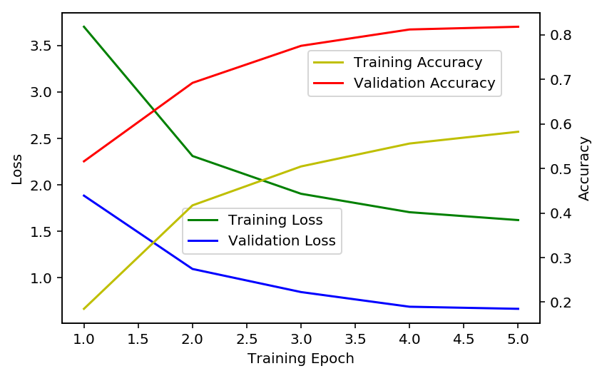

```python
# Train model
with active_session():
    history, best_epoch = train_model(model=model, dataloaders=dataloaders, criterion=nn.NLLLoss(),
                                      optimizer=optimizer, gpu=True, start_epoch=1, epochs=5,
                                      train_history=None)

plot_history(history)
```

We would like to test that training and history tracking is correctly restarted on resumption of training:

```
---------------------
TRAIN completed in 138s. Loss: 1.5424, Acc: 0.6039
VALID completed in 17s. Loss: 0.6208, Acc: 0.8362

---------------------
TRAIN completed in 138s. Loss: 1.4490, Acc: 0.6287
VALID completed in 17s. Loss: 0.6306, Acc: 0.8386

Training complete in 5m 11s. Best Validation Acc: 0.8386, achieved after epoch 7
```

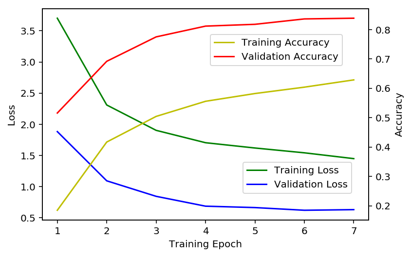

```python
# Test resume training
with active_session():
    history, best_epoch = train_model(model=model, dataloaders=dataloaders, criterion=criterion,
                                      optimizer=optimizer, gpu=True, start_epoch=best_epoch + 1, epochs=2,
                                      train_history=history)

plot_history(history)
```

As can be seen from the plot above, we have not fully saturated on validation accuracy (and loss) and can continue training the model for further performance improvement without worrying about overfitting.

## Testing your network

It's good practice to test your trained network on test data, images the network has never seen either in training or validation. This will give you a good estimate for the model's performance on completely new images. Run the test images through the network and measure the accuracy, the same way you did validation. You should be able to reach around 70% accuracy on the test set if the model has been trained well.

```python
def test_model(model, dataloader, gpu=False):
    """Tests model performance on a data from dataloader and prints accuracy.

    Args:
        model (torchvision model)
        dataloader (DataLoader)
        gpu (bool): Use GPU if True, otherwise CPU
    """

    # Set evaluation mode
    model.eval()

    device = select_device(gpu)

    # Send model to device
    model.to(device)

    # Run validation on TEST data
    running_corrects = 0
    for inputs, labels in dataloader:
        # send inputs, labels to device
        inputs, labels = inputs.to(device), labels.to(device)

        with torch.no_grad():
            # forward propagation
            logps = model(inputs)
            # caluclate loss
            loss = criterion(logps, labels)

        # Running accuracy
        ps = torch.exp(logps)  # probabilities
        _, predictions = ps.topk(1, dim=1)   # top predictions
        equals = predictions == labels.view(*predictions.shape)
        running_corrects += torch.sum(equals.type(torch.FloatTensor)).item()

    # Calculate accuracy
    test_acc = running_corrects / len(dataloaders['test'].dataset)

    print(f'Test accuracy is {test_acc:.4f}')
```

```python
# Test model
test_model(model, dataloaders['test'], gpu=True)
```

```
Test accuracy is 0.7973
```

Our initial training results are not bad even after only 7 training epochs with 79.73% classification accuracy on the Test data set.

## Save the checkpoint

Now that your network is trained, save the model so you can load it later for making predictions. You probably want to save other things such as the mapping of classes to indices which you get from one of the image datasets: `image_datasets['train'].class_to_idx`. You can attach this to the model as an attribute which makes inference easier later on.

`model.class_to_idx = image_datasets['train'].class_to_idx`

Remember that you'll want to completely rebuild the model later so you can use it for inference. Make sure to include any information you need in the checkpoint. If you want to load the model and keep training, you'll want to save the number of epochs as well as the optimizer state, `optimizer.state_dict`. You'll likely want to use this trained model in the next part of the project, so best to save it now.

```python
def save_checkpoint(filepath, epoch, model, optimizer, history):
    """Saves PyTorch checkpoint on CPU with provided model, optimizer and training history

    Args:
        filepath (str): save file path
        epoch (int): training epoch being saved
        model: model for which checkpoint is being saved
        optimizer (torch.optim.Optimizer)
        history (dict(dict)): nested dictionary containing training and validation losses and accuracies
    """

    print('Saving checkpoint...')

    model.to('cpu')

    checkpoint = {
        'arch': model.arch,
        'output_size': model.output_size,
        'class_to_idx': model.class_to_idx,
        'hidden_layers': model.hidden_layers,
        'drop_p': model.drop_p,
        'history': history,
        'epoch': best_epoch,
        'model_state_dict': model.state_dict(),
        'optimizer_state_dict': optimizer.state_dict()
    }

    # Save checkpoint
    torch.save(checkpoint, filepath)

    file_size = os.path.getsize(filepath)
    print(f'Checkpoint saved: {(file_size / 1e9):.2f}Gb')
```

```python
# save checkpoint with model/optimizer after last training step
save_checkpoint('checkpoint.pth', best_epoch, model, optimizer, history)
```

```
Saving checkpoint...
Checkpoint saved: 0.69Gb
```

## Loading the checkpoint

At this point it's good to write a function that can load a checkpoint and rebuild the model. That way you can come back to this project and keep working on it without having to retrain the network.

```python
def load_checkpoint(checkpoint_path, load_optimizer=False, gpu=False):
    """Loads checkpoint and rebuilds pretrained model and optinal optimizer on device specified by gpu(bool)

    Args:
        checkpoint_path (str): checkpoint file path
        load_optmizer (bool): True: creates an optimizer and loads state_dict
                              False: does not create an optimizer
        gpu (bool): True attempt to load on GPU. If GPU is not available, user is notified

    Returns:
        model (): rebuilt pre-trained model
        optimizer (optim.Optimizer, None): optimizer  if load_optimizer==True, None otherwise
    """

    print('Loading model checkpoint...')

    # select device and check if gpu is available if requested
    device = select_device(gpu)

    # load checkpoint.
    # IMPORTANT Assumes checkpoint is saved on CPU
    if gpu:
        checkpoint = torch.load(checkpoint_path, map_location='cuda:0')
    else:
        checkpoint = torch.load(checkpoint_path, map_location='cpu')

    epoch = checkpoint['epoch']
    history = checkpoint['history']

    # Build model
    print('Re-building model...')
    model = create_model(arch=checkpoint['arch'],
                         output_size=checkpoint['output_size'],
                         class_to_idx=checkpoint['class_to_idx'],
                         hidden_layers=checkpoint['hidden_layers'],
                         drop_p=checkpoint['drop_p'])

    # Load model weights
    print('Loading state dictionary...')
    model.load_state_dict(checkpoint['model_state_dict'])
    model.to(device)

    # Create optimizer
    if load_optimizer:
        print('Loading optimizer...')
        optimizer = create_optimizer(model=model)
        optimizer.load_state_dict(checkpoint['optimizer_state_dict'])
    else:
        optimizer = None

    # Summarize training results
    print(f'Model checkpoint epoch {epoch} successfully loaded.')

    return model, optimizer, epoch, history
```

```
Loading model checkpoint...
Re-building model...
Loading state dictionary...
Loading optimizer...
Model checkpoint epoch 7 successfully loaded.
```

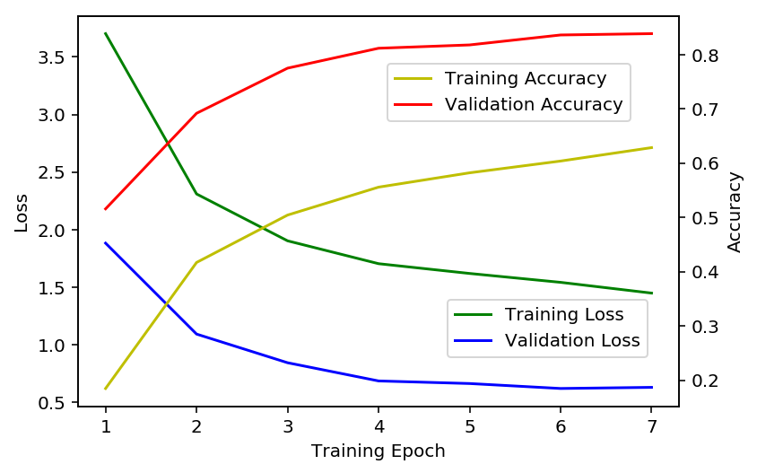

```python
# test load_checkpoint for training continuation (use GPU)
model, optimizer, epoch, history = load_checkpoint('checkpoint.pth', load_optimizer=True, gpu=True)
plot_history(history)
```

```
---------------------
TRAIN completed in 138s. Loss: 1.3889, Acc: 0.6368
VALID completed in 17s. Loss: 0.5359, Acc: 0.8631

---------------------
TRAIN completed in 138s. Loss: 1.4153, Acc: 0.6352
VALID completed in 17s. Loss: 0.5376, Acc: 0.8680

Training complete in 5m 11s. Best Validation Acc: 0.8680, achieved after epoch 9
```

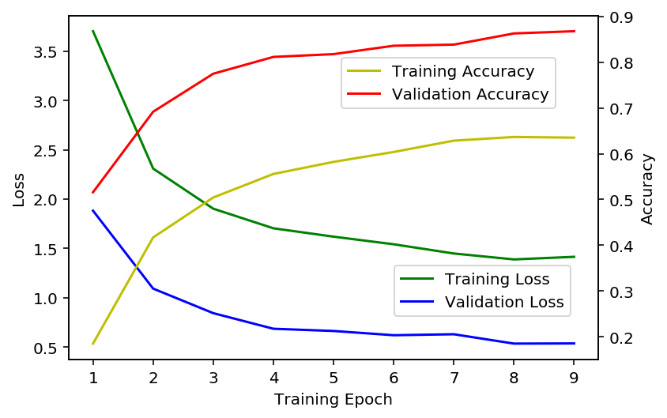

```python
# test resume training on gpu
criterion = nn.NLLLoss()
with active_session():
    history, best_epoch = train_model(model=model, dataloaders=dataloaders, criterion=criterion,
                                      optimizer=optimizer, gpu=True, start_epoch=epoch + 1, epochs=2,
                                      train_history=history)
plot_history(history)
```

As seen from figure above, we still haven't fully saturated in validation accuracy after 9 training epochs and continue improving model performance since our last check after 7 training epochs. Out of curiosity, we can check if we perform better on unseen Test data (**IMPORTANT**: we cannot make any decisions about model training based on this Test data set result, since using test data more than once will bias our decision on the number of training epochs hyperparameter).

```python
test_model(model, dataloaders['test'], gpu=True)
```

```
Test accuracy is 0.8230
```

Note that our accuracy of classification on the Test data set improved from 79.73% to 82.3% with two additional training epochs. Again, we cannot use this result to make a decision when to stop training the model since Test data has now been "seen" by the training process more than once.

# Inference for classification

Now you'll write a function to use a trained network for inference. That is, you'll pass an image into the network and predict the class of the flower in the image. Write a function called `predict` that takes an image and a model, then returns the top $K$ most likely classes along with the probabilities. It should look like

```
probs, classes = predict(image_path, model)
print(probs)
print(classes)
> [ 0.01558163  0.01541934  0.01452626  0.01443549  0.01407339]
> ['70', '3', '45', '62', '55']
```

First you'll need to handle processing the input image such that it can be used in your network.

## Image Preprocessing

You'll want to use `PIL` to load the image ([documentation](https://pillow.readthedocs.io/en/latest/reference/Image.html)). It's best to write a function that preprocesses the image so it can be used as input for the model. This function should process the images in the same manner used for training.

First, resize the images where the shortest side is 256 pixels, keeping the aspect ratio. This can be done with the [`thumbnail`](http://pillow.readthedocs.io/en/3.1.x/reference/Image.html#PIL.Image.Image.thumbnail) or [`resize`](http://pillow.readthedocs.io/en/3.1.x/reference/Image.html#PIL.Image.Image.thumbnail) methods. Then you'll need to crop out the center 224x224 portion of the image.

Color channels of images are typically encoded as integers 0-255, but the model expected floats 0-1. You'll need to convert the values. It's easiest with a Numpy array, which you can get from a PIL image like so `np_image = np.array(pil_image)`.

As before, the network expects the images to be normalized in a specific way. For the means, it's `[0.485, 0.456, 0.406]` and for the standard deviations `[0.229, 0.224, 0.225]`. You'll want to subtract the means from each color channel, then divide by the standard deviation.

And finally, PyTorch expects the color channel to be the first dimension but it's the third dimension in the PIL image and Numpy array. You can reorder dimensions using [`ndarray.transpose`](https://docs.scipy.org/doc/numpy-1.13.0/reference/generated/numpy.ndarray.transpose.html). The color channel needs to be first and retain the order of the other two dimensions.

```python
def process_image(image):
    ''' Scales, crops, and normalizes a PIL image for a PyTorch model,
        returns an Numpy array
    '''
    IMG_SIZE = 224  # Size of images used for training
    IMG_MEAN = [0.485, 0.456, 0.406]
    IMG_SDEV = [0.229, 0.224, 0.225]

    # Resize to 256 max dim
    if image.size[0] >= image.size[1]:
        image.thumbnail((256, image.size[1] * 256 // image.size[0]))
    else:
        image.thumbnail((image.size[0] * 256 // image.size[1], 256))

    # Center crop
    crop_box = ((image.size[0] - IMG_SIZE) // 2, (image.size[1] - IMG_SIZE) // 2,
                (image.size[0] + IMG_SIZE) // 2 , (image.size[1] + IMG_SIZE) // 2)
    image = image.crop(crop_box)

    # Convert to np.array and rescale color channels to 0-1
    image = np.array(image) / 255

    # Normalize image
    image = (image - np.array(IMG_MEAN)) / np.array(IMG_SDEV)

    # Rearrange to make color channel first dimension
    image = image.transpose(2, 0, 1)

    return image
```

To check your work, the function below converts a PyTorch tensor and displays it in the notebook. If your `process_image` function works, running the output through this function should return the original image (except for the cropped out portions).

```python
def imshow(image, ax=None, title=None):
    """Imshow for Tensor."""

    IMG_SIZE = 224  # Size of images used for training
    IMG_MEAN = [0.485, 0.456, 0.406]
    IMG_SDEV = [0.229, 0.224, 0.225]

    if ax is None:
        fig, ax = plt.subplots()

    # PyTorch tensors assume the color channel is the first dimension
    # but matplotlib assumes is the third dimension
    image = image.transpose((1, 2, 0))

    # Undo preprocessing
    image = np.array(IMG_SDEV) * image + np.array(IMG_MEAN)

    # Image needs to be clipped between 0 and 1 or it looks like noise when displayed
    image = np.clip(image, 0, 1)

    ax.imshow(image)

    return ax
```

```
Processed image shape (3, 224, 224)
```

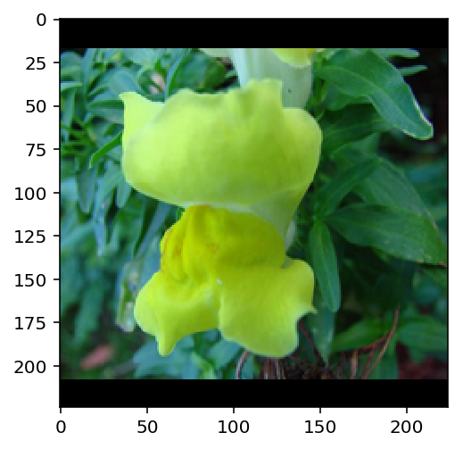

```python
img = Image.open('flowers/train/11/image_03095.jpg')
processed_img = process_image(img)
print(f'Processed image shape {processed_img.shape}')
imshow(processed_img)
```

## Class Prediction

Once you can get images in the correct format, it's time to write a function for making predictions with your model. A common practice is to predict the top 5 or so (usually called top-$K$) most probable classes. You'll want to calculate the class probabilities then find the $K$ largest values.

To get the top $K$ largest values in a tensor use [`x.topk(k)`](http://pytorch.org/docs/master/torch.html#torch.topk). This method returns both the highest `k` probabilities and the indices of those probabilities corresponding to the classes. You need to convert from these indices to the actual class labels using `class_to_idx` which hopefully you added to the model or from an `ImageFolder` you used to load the data (see here). Make sure to invert the dictionary so you get a mapping from index to class as well.

Again, this method should take a path to an image and a model checkpoint, then return the probabilities and classes.

```
probs, classes = predict(image_path, model)
print(probs)
print(classes)
> [ 0.01558163  0.01541934  0.01452626  0.01443549  0.01407339]
> ['70', '3', '45', '62', '55']
```

```python
def predict(img_path, checkpoint_path, topk=5, gpu=False):
    """ Predict the class (or classes) of an image using a trained deep learning model.

    Args:
        img_path (str): path to image for classfication
        checkpoint_path (str): path to PyTorch model checkpoint
        topk (int): number of top predicitions to return

    Returns:
        probs ([float]): list of predicition probabilities
        classes ([str]): list of predicted class indices
        class_names ([str]): list of predicted class names
    """

    # Select device
    device = select_device(gpu)

    # Load and process image
    img = process_image(Image.open(img_path))

    # Convert image from numpy to torch
    img_tensor = torch.from_numpy(np.expand_dims(img, axis=0)).type(torch.FloatTensor)

    # load model
    # model moved to device specified by gpu(bool) on load
    model, _, _, _ = load_checkpoint(checkpoint_path, load_optimizer=False, gpu=gpu)

    # image to device.

    img_tensor = img_tensor.to(device)

    # Classify image
    model.eval()
    with torch.no_grad():
        output = torch.exp(model(img_tensor))

    # Get topk probabilities and class indices
    probs, preds = output.topk(topk, dim=1)
    probs, preds = probs.tolist()[0], preds.tolist()[0]

    # convert indeces to named classes using model.class_to_idx and cat_to_name
    class_dict = {val: key for key, val in model.class_to_idx.items()}
    classes = [class_dict[x] for x in preds]
    class_names = [cat_to_name[x] for x in classes]

    return probs, classes, class_names
```

```python
probs, classes, class_names = predict('flowers/train/11/image_03095.jpg', 'checkpoint.pth', topk=5, gpu=True)
print(probs)
print(classes)
print(class_names)
```

```
Loading model checkpoint...
Re-building model...
Loading state dictionary...
Model checkpoint epoch 7 successfully loaded.
[0.6611559987068176, 0.3316136598587036, 0.0029923419933766127, 0.002936264732852578, 0.0002819345099851489]
['11', '74', '96', '4', '68']
['snapdragon', 'rose', 'camellia', 'sweet pea', 'bearded iris']
```

## Sanity Checking

Now that you can use a trained model for predictions, check to make sure it makes sense. Even if the testing accuracy is high, it's always good to check that there aren't obvious bugs. Use `matplotlib` to plot the probabilities for the top 5 classes as a bar graph, along with the input image. It should look like this:

[figure not shown]

You can convert from the class integer encoding to actual flower names with the `cat_to_name.json` file (should have been loaded earlier in the notebook). To show a PyTorch tensor as an image, use the `imshow` function defined above.

```python
# TODO: Display an image along with the top 5 classes
def display_classification(img_path, checkpoint_path, topk=5):

    # Get model predictions
    probs, classes, class_names = predict(img_path, checkpoint_path, topk=topk, gpu=False)

    # Setup plot gird and title
    fig = plt.figure(figsize=(4, 5.4))
    ax1 = plt.subplot2grid((2, 1), (0, 0))
    ax2 = plt.subplot2grid((2, 1), (1, 0))
    fig.suptitle(class_names[0].capitalize(), x=0.6, y=1, fontsize=16)

    # Display image
    ax1.imshow(Image.open(img_path))
    ax1.set_xticks([])
    ax1.set_yticks([])

    # Display predicted classes and probabilities
    y = np.arange(len(class_names))  # setup y axis grid
    ax2.barh(y, probs)
    ax2.set_yticks(y)
    ax2.set_yticklabels(class_names)
    ax2.invert_yaxis()  # prediction with highest probability on top
    ax2.set_xlabel('Prediction probability')

    # Adjust layout
    fig.tight_layout()
```

```
Loading model checkpoint...
Re-building model...
Loading state dictionary...
Model checkpoint epoch 7 successfully loaded.
```

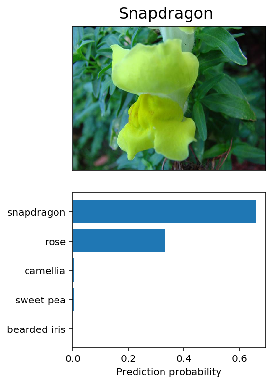

```python
display_classification('flowers/train/11/image_03095.jpg', 'checkpoint.pth', topk=5)
```